# 04_ALT_status

Andrea Polazzi

2026-03-12

# Setup

Let’s load the dataset and have a look at it.

```r
library(readxl)
data <- read_xlsx('../data/raw/PCAWG_variables_PCA_woK.xlsx')
summary(data)
```

```
##  icgc_donor_id      histology_abbreviation deNonneville2020.ALT_status
##  Length:2014        Length:2014            Length:2014
##  Class :character   Class :character       Class :character
##  Mode  :character   Mode  :character       Mode  :character
##
##
##
##
##  TF_rate.total      telomere_insertions rate (tel_ins/cov*purity)
##  Min.   : 0.00000   Min.   :0.00000
##  1st Qu.: 0.00000   1st Qu.:0.00000
##  Median : 0.03931   Median :0.00000
##  Mean   : 0.13568   Mean   :0.03307
##  3rd Qu.: 0.10251   3rd Qu.:0.02195
##  Max.   :19.73776   Max.   :5.38979
##
##  tel_content_log2    TERT_FPKM         ATAGGG_singleton_dist
##  Min.   :-4.00250   Length:2014        Length:2014
##  1st Qu.:-0.92876   Class :character   Class :character
##  Median :-0.52968   Mode  :character   Mode  :character
##  Mean   :-0.43589
##  3rd Qu.:-0.07054
##  Max.   : 3.84469
##
##  CTAGGG_singleton_dist GTAGGG_singleton_dist TAAGGG_singleton_dist
##  Min.   :-3.49674      Min.   :-2.981384     Length:2014
##  1st Qu.:-0.38418      1st Qu.:-0.359368     Class :character
##  Median : 0.05423      Median : 0.017444     Mode  :character
##  Mean   : 0.06588      Mean   : 0.001582
##  3rd Qu.: 0.53662      3rd Qu.: 0.352901
##  Max.   : 7.80772      Max.   : 4.253404
##  NA's   :2
##  TCAGGG_singleton_dist TGAGGG_singleton_dist TTCGGG_singleton_dist
##  Length:2014           Min.   :-5.27154      Length:2014
##  Class :character      1st Qu.:-0.37005      Class :character
##  Mode  :character      Median : 0.06673      Mode  :character
##                        Mean   : 0.07103
##                        3rd Qu.: 0.46860
##                        Max.   : 6.67267
##
##  TTGGGG_singleton_dist TTTGGG_singleton_dist
##  Length:2014           Min.   :-4.1941
##  Class :character      1st Qu.:-0.5610
##  Mode  :character      Median :-0.1030
##                        Mean   :-0.1309
##                        3rd Qu.: 0.3465
##                        Max.   : 2.7484
##
```

We have to rename columns, set categories as factors, deal with NA values, and handle typing.

```r
source('../scripts/clean_columns.R')
clean_data <- clean_pcawg_data(data)
summary(clean_data)
```

```
##    donor_id                 cancer_type      alt_status      tf_rate
##  Length:2014        Liver-HCC     : 221   ALT-low :1844   Min.   : 0.00000
##  Class :character   Panc-AdenoCA  : 196   ALT-high: 170   1st Qu.: 0.00000
##  Mode  :character   Breast-AdenoCA: 161                   Median : 0.03931
##                     Prost-AdenoCA : 136                   Mean   : 0.13568
##                     Kidney-RCC    : 126                   3rd Qu.: 0.10251
##                     CNS-Medullo   : 117                   Max.   :19.73776
##                     (Other)       :1057
##  telomere_insertion_rate telomere_content_log2   TERT_FPKM
##  Min.   :0.00000         Min.   :-4.00250      Min.   : 0.00000
##  1st Qu.:0.00000         1st Qu.:-0.92876      1st Qu.: 0.02069
##  Median :0.00000         Median :-0.52968      Median : 0.10630
##  Mean   :0.03307         Mean   :-0.43589      Mean   : 0.90171
##  3rd Qu.:0.02195         3rd Qu.:-0.07054      3rd Qu.: 0.37979
##  Max.   :5.38979         Max.   : 3.84469      Max.   :53.76790
##                                                NA's   :1166
##  ATAGGG_singleton_dist CTAGGG_singleton_dist GTAGGG_singleton_dist
##  Min.   :-4.35757      Min.   :-3.49674      Min.   :-2.981384
##  1st Qu.:-0.68156      1st Qu.:-0.38418      1st Qu.:-0.359368
##  Median :-0.03350      Median : 0.05423      Median : 0.017444
##  Mean   :-0.06042      Mean   : 0.06588      Mean   : 0.001582
##  3rd Qu.: 0.57645      3rd Qu.: 0.53662      3rd Qu.: 0.352901
##  Max.   : 4.47470      Max.   : 7.80772      Max.   : 4.253404
##  NA's   :28            NA's   :2
##  TAAGGG_singleton_dist TCAGGG_singleton_dist TGAGGG_singleton_dist
##  Min.   :-4.67195      Min.   :-4.27208      Min.   :-5.27154
##  1st Qu.:-0.53849      1st Qu.:-0.56813      1st Qu.:-0.37005
##  Median : 0.08092      Median : 0.02901      Median : 0.06673
##  Mean   : 0.06257      Mean   : 0.08148      Mean   : 0.07103
##  3rd Qu.: 0.67706      3rd Qu.: 0.70046      3rd Qu.: 0.46860
##  Max.   : 3.87943      Max.   : 7.64722      Max.   : 6.67267
##  NA's   :28            NA's   :18
##  TTCGGG_singleton_dist TTGGGG_singleton_dist TTTGGG_singleton_dist
##  Min.   :-3.848796     Min.   :-3.109601     Min.   :-4.1941
##  1st Qu.:-0.568133     1st Qu.:-0.417046     1st Qu.:-0.5610
##  Median : 0.007297     Median :-0.019229     Median :-0.1030
##  Mean   : 0.102063     Mean   : 0.002303     Mean   :-0.1309
##  3rd Qu.: 0.573244     3rd Qu.: 0.429475     3rd Qu.: 0.3465
##  Max.   : 8.739318     Max.   : 4.584889     Max.   : 2.7484
##  NA's   :5             NA's   :2
```

# Define the TVR modeling dataset

Before doing PCA or classification, it is useful to **define a single dataset** containing only the response variable and the TVR features of interest. In this way, NA handling is done once, row alignment is preserved, and the same samples are used consistently throughout the analysis.

```r
tvr_cols <- grep("_dist$", names(clean_data), value = TRUE)

model_data <- clean_data[, c("alt_status", tvr_cols)]
model_data <- model_data[complete.cases(model_data), ]

summary(model_data)
```

```
##     alt_status   ATAGGG_singleton_dist CTAGGG_singleton_dist
##  ALT-low :1778   Min.   :-4.35757      Min.   :-3.49674
##  ALT-high: 165   1st Qu.:-0.67617      1st Qu.:-0.37981
##                  Median :-0.03391      Median : 0.05669
##                  Mean   :-0.05956      Mean   : 0.06887
##                  3rd Qu.: 0.57536      3rd Qu.: 0.54136
##                  Max.   : 4.47470      Max.   : 7.80772
##  GTAGGG_singleton_dist TAAGGG_singleton_dist TCAGGG_singleton_dist
##  Min.   :-2.684633     Min.   :-4.67195      Min.   :-4.27208
##  1st Qu.:-0.352465     1st Qu.:-0.53803      1st Qu.:-0.56842
##  Median : 0.021543     Median : 0.06787      Median : 0.01256
##  Mean   : 0.005307     Mean   : 0.05380      Mean   : 0.07617
##  3rd Qu.: 0.349002     3rd Qu.: 0.66393      3rd Qu.: 0.68858
##  Max.   : 4.253404     Max.   : 3.87943      Max.   : 7.64722
##  TGAGGG_singleton_dist TTCGGG_singleton_dist TTGGGG_singleton_dist
##  Min.   :-5.27154      Min.   :-3.848796     Min.   :-3.109601
##  1st Qu.:-0.36487      1st Qu.:-0.554975     1st Qu.:-0.407457
##  Median : 0.07004      Median : 0.008381     Median :-0.016287
##  Mean   : 0.07612      Mean   : 0.105562     Mean   : 0.008671
##  3rd Qu.: 0.46864      3rd Qu.: 0.573689     3rd Qu.: 0.427547
##  Max.   : 6.67267      Max.   : 8.739318     Max.   : 4.584889
##  TTTGGG_singleton_dist
##  Min.   :-4.1941
##  1st Qu.:-0.5597
##  Median :-0.1058
##  Mean   :-0.1321
##  3rd Qu.: 0.3447
##  Max.   : 2.7484
```

# PCA with TVR motifs

Here we perform PCA using the TVR motif variables only.

```r
X <- scale(model_data[, tvr_cols])
pca <- prcomp(X, center = TRUE, scale. = TRUE)
summary(pca)
```

```
## Importance of components:
##                           PC1    PC2    PC3     PC4     PC5     PC6     PC7
## Standard deviation     1.6291 1.1822 1.0218 0.92287 0.84810 0.83513 0.77922
## Proportion of Variance 0.2949 0.1553 0.1160 0.09463 0.07992 0.07749 0.06746
## Cumulative Proportion  0.2949 0.4502 0.5662 0.66080 0.74072 0.81822 0.88568
##                            PC8    PC9
## Standard deviation     0.74408 0.6894
## Proportion of Variance 0.06152 0.0528
## Cumulative Proportion  0.94720 1.0000
```

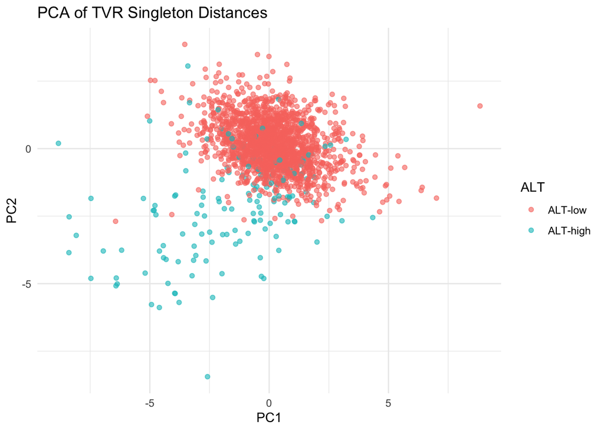

```r
library(ggplot2)
pca_df <- data.frame(
  PC1 = pca$x[,1],
  PC2 = pca$x[,2],
  ALT = model_data$alt_status
)

ggplot(pca_df, aes(PC1, PC2, color = ALT)) +
  geom_point(alpha = 0.6) +
  theme_minimal() +
  labs(
    title = "PCA of TVR Singleton Distances",
    x = "PC1",
    y = "PC2"
  )
```

```r
pca$rotation
```

```
##                                PC1         PC2         PC3         PC4
## ATAGGG_singleton_dist -0.330287444  0.27090271  0.28868087  0.16249320
## CTAGGG_singleton_dist -0.391002639  0.26152524  0.04668044  0.43495215
## GTAGGG_singleton_dist -0.276347829 -0.16556181  0.70836447 -0.15135998
## TAAGGG_singleton_dist -0.265756581  0.33190411 -0.26148451 -0.70736987
## TCAGGG_singleton_dist -0.412493086  0.10914703 -0.22541733  0.33198915
## TGAGGG_singleton_dist -0.374640798 -0.33357021 -0.04987811 -0.32096765
## TTCGGG_singleton_dist -0.401618597 -0.41408298  0.08014537 -0.07973415
## TTGGGG_singleton_dist -0.345285042  0.02997012 -0.46646479  0.06347235
## TTTGGG_singleton_dist -0.002631801  0.65199704  0.25887535 -0.19366803
##                               PC5         PC6         PC7         PC8
## ATAGGG_singleton_dist  0.79060731  0.08938061 -0.19300657  0.18988190
## CTAGGG_singleton_dist -0.14766205 -0.27470438  0.04783054 -0.65601994
## GTAGGG_singleton_dist -0.20889960  0.18801019  0.38873589 -0.08817076
## TAAGGG_singleton_dist  0.16035693 -0.26981778  0.38004702 -0.08129033
## TCAGGG_singleton_dist -0.28584022 -0.33142726  0.11553167  0.58205464
## TGAGGG_singleton_dist -0.07891616 -0.16552156 -0.70564053 -0.19048699
## TTCGGG_singleton_dist -0.06505938  0.06340890  0.06341891  0.29243304
## TTGGGG_singleton_dist -0.03918376  0.78277660  0.08355097 -0.13595693
## TTTGGG_singleton_dist -0.43598410  0.23323342 -0.37766458  0.20031534
##                               PC9
## ATAGGG_singleton_dist -0.03775922
## CTAGGG_singleton_dist  0.23967175
## GTAGGG_singleton_dist -0.36558795
## TAAGGG_singleton_dist  0.03011620
## TCAGGG_singleton_dist -0.33648592
## TGAGGG_singleton_dist -0.27391264
## TTCGGG_singleton_dist  0.74609954
## TTGGGG_singleton_dist -0.13609654
## TTTGGG_singleton_dist  0.20768355
```

## PCA biplot of TVR motifs

We see, using the info stored in the loadings of the PCs, what motifs drive the components variability.

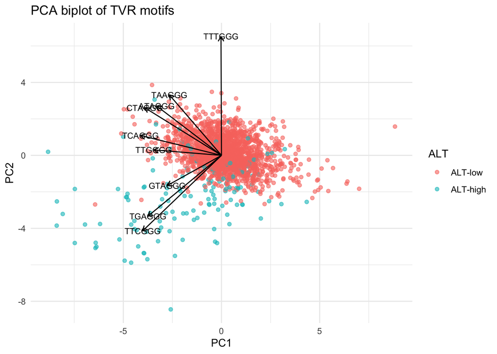

```r
# sample coordinates
scores <- data.frame(
  PC1 = pca$x[,1],
  PC2 = pca$x[,2],
  ALT = model_data$alt_status
)

# motif vectors
loadings <- data.frame(
  PC1 = pca$rotation[,1],
  PC2 = pca$rotation[,2],
  motif = sapply(strsplit(rownames(pca$rotation), split = '_', fixed = TRUE), `[`, 1)
)

# scale the loadings (smaller than sample coordinates) to make arrows more visible
loadings$PC1 <- loadings$PC1 * 10
loadings$PC2 <- loadings$PC2 * 10

library(ggplot2)

ggplot(scores, aes(PC1, PC2, color = ALT)) +
  geom_point(alpha = 0.6) +
  geom_segment(data = loadings,
               aes(x = 0, y = 0, xend = PC1, yend = PC2),
               arrow = arrow(length = unit(0.2,"cm")),
               inherit.aes = FALSE,
               color = "black") +
  geom_text(data = loadings,
            aes(x = PC1, y = PC2, label = motif),
            inherit.aes = FALSE,
            size = 3) +
  theme_minimal() +
  labs(
    title = "PCA biplot of TVR motifs",
    x = "PC1",
    y = "PC2"
  )
```

# Supervised classification

Now we move on to supervised classification. The goal is to **test whether TVR motifs can predict ALT status**, and then see if adding other features improves performance. Conceptually, we can follow this pipeline:

- 1 split train/test
- 2 define feature sets
- 3 train models
- 4 cross-validate
- 5 evaluate performance
- 6 compute feature importance

## Split the dataset

First we randomly split the dataset in **training set** and **test set**, and check that both ALT+ and ALT- are sufficiently represented in the two splits.

```r
set.seed(21)
train_index <- sample(1:nrow(model_data), size = 0.8 * nrow(model_data))
train <- model_data[train_index, ]
test <- model_data[-train_index, ]

table(train$alt_status, dnn = 'train')
```

```
## train
##  ALT-low ALT-high
##     1416      138
```

```r
table(test$alt_status, dnn = 'test')
```

```
## test
##  ALT-low ALT-high
##      362       27
```

## Define feature set

We extract the TVR features, storing predictors and response in distinct objects.

```r
x_train <- train[, tvr_cols]
x_test <- test[, tvr_cols]
y_train <- train$alt_status
y_test <- test$alt_status
```

## First classifier: logistic regression

We train a first simple logistic regression model.

```r
train_glm <- train
train_glm$alt_status <- relevel(train_glm$alt_status, ref = "ALT-low")
test_glm <- test
test_glm$alt_status <- factor(test_glm$alt_status, levels = levels(train_glm$alt_status))

logreg_model <- glm(
  alt_status ~ .,
  data = train_glm,
  family = 'binomial'
)

prob <- predict(logreg_model, newdata = test_glm, type = 'response')
```

### Evaluate performance

The choice of ROC/AUC instead of simple accuracy is due to the fact that **our dataset is unbalanced**: the sample ratio of ALT-low to ALT-high is approximately 10:1. This means that a naive classifier, for example one assigning ALT-low labels to all observations, would have a good-looking accuracy.

Therefore **accuracy is a simple but misleading metric** in this case. Since our logistic regression model predicts the probability of an observation belonging to the ALT-high class, we can use ROC/AUC to evaluate the performance of the model.

```r
library(pROC)
```

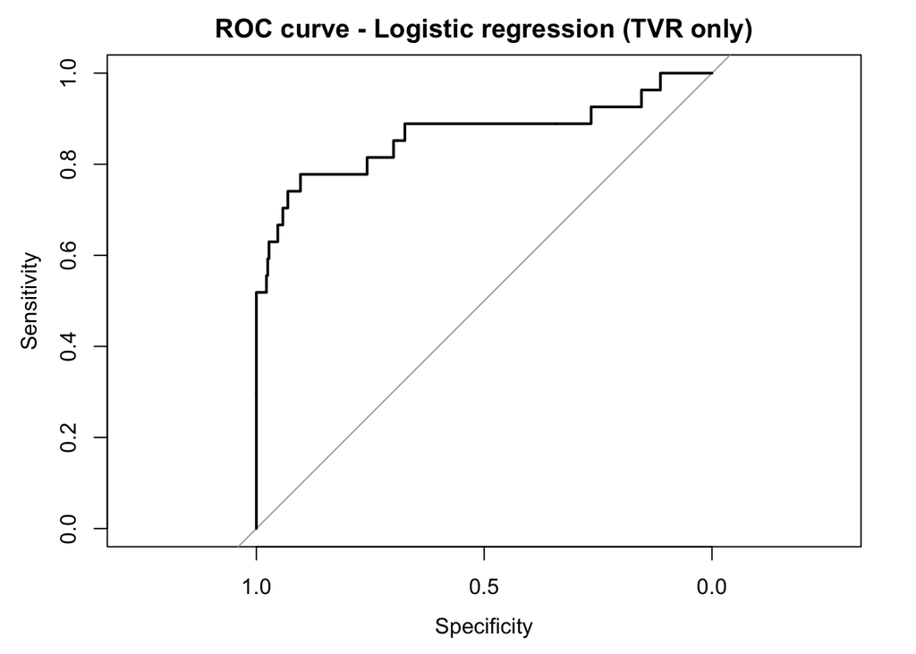

```r
roc_obj <- roc(
  response = test_glm$alt_status,
  predictor = prob,
  levels = c("ALT-low", "ALT-high"),
  direction = "<"
)

plot(roc_obj, main = "ROC curve - Logistic regression (TVR only)", xlim = c(1, 0))
```

```r
auc(roc_obj)
```

```
## Area under the curve: 0.8636
```

And we can see that the performance of this model is **pretty good** (AUC=0.8636), supporting the idea that **TVR motifs** already contain **useful predictive information**. The steep initial rise of the curve suggests that the model can correctly identify many ALT-high tumors while maintaining a **low false positive rate**.

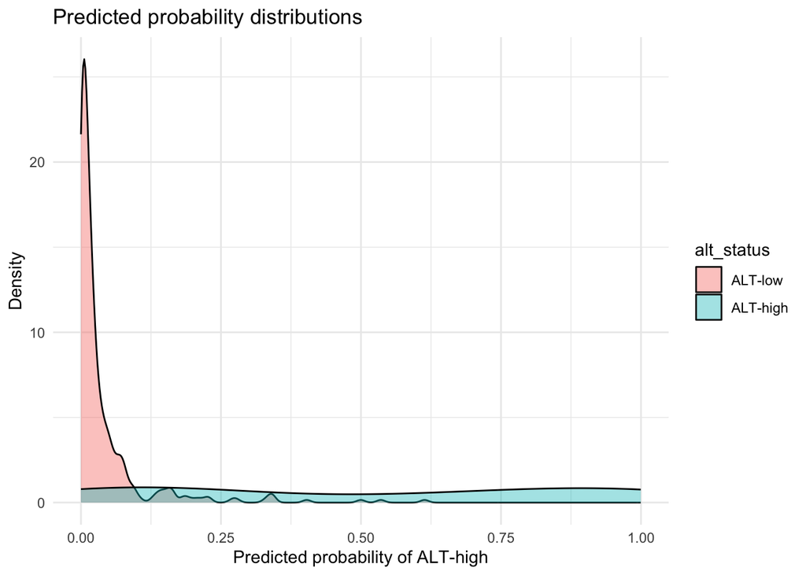

```r
prob_df <- data.frame(
  prob = prob,
  alt_status = test_glm$alt_status
)

library(ggplot2)

ggplot(prob_df, aes(x = prob, fill = alt_status)) +
  geom_density(alpha = 0.4) +
  theme_minimal() +
  labs(
    title = "Predicted probability distributions",
    x = "Predicted probability of ALT-high",
    y = "Density"
  )
```

Samples labeled ALT-low are almost entirely concentrated near zero probability of ALT-high, indicating that the model assigns them consistently low ALT probabilities. In contrast, **ALT-high samples display a broader distribution**, with many receiving moderate to high predicted probabilities. This partial separation suggests that the TVR motif features contain meaningful information about ALT status, although some overlap indicates that **not all ALT-high tumors are equally distinguishable** based on these features alone.

### Other metrics

```r
pred_class <- ifelse(prob >= 0.5, "ALT-high", "ALT-low")
pred_class <- factor(pred_class, levels = c("ALT-low", "ALT-high"))

library(caret)
confusionMatrix(pred_class, test_glm$alt_status, positive = 'ALT-high')
```

```
## Confusion Matrix and Statistics
##
##           Reference
## Prediction ALT-low ALT-high
##   ALT-low      360       13
##   ALT-high       2       14
##
##                Accuracy : 0.9614
##                  95% CI : (0.9372, 0.9783)
##     No Information Rate : 0.9306
##     P-Value [Acc > NIR] : 0.007155
##
##                   Kappa : 0.6322
##
##  Mcnemar's Test P-Value : 0.009823
##
##             Sensitivity : 0.51852
##             Specificity : 0.99448
##          Pos Pred Value : 0.87500
##          Neg Pred Value : 0.96515
##              Prevalence : 0.06941
##          Detection Rate : 0.03599
##    Detection Prevalence : 0.04113
##       Balanced Accuracy : 0.75650
##
##        'Positive' Class : ALT-high
##
```

The **confusion matrix** shows that the logistic regression model achieves **high overall accuracy** (96.1%), which is significantly better than the no-information rate (93%), indicating that the model performs meaningfully better than always predicting the majority class. The model exhibits **very high specificity** (99.4%), meaning it almost never misclassifies ALT-low tumors as ALT-high, and a **high precision** (87.5%) for ALT-high predictions, indicating that when the model predicts ALT-high it is usually correct.

However, the **sensitivity is moderate** (~52%), meaning that only about half of the true ALT-high tumors are detected. The resulting **balanced accuracy** of ~76% reflects this asymmetry: the model is very effective at identifying ALT-low samples but less sensitive in detecting all ALT-high cases, suggesting that while TVR motifs provide useful predictive signal, they **do not fully capture the variability of ALT tumors**.

## Second classifier: Random Forest

A random forest can capture nonlinear relationships and interactions between TVR motifs that are not modeled by logistic regression. We therefore fit the same prediction task using RF on the same training and test sets.

```r
library(randomForest)
rf_model <- randomForest(
  alt_status ~ .,
  data = train,
  ntree = 500,
  importance = TRUE
)

rf_model
```

```
##
## Call:
##  randomForest(formula = alt_status ~ ., data = train, ntree = 500,      importance = TRUE)
##                Type of random forest: classification
##                      Number of trees: 500
## No. of variables tried at each split: 3
##
##         OOB estimate of  error rate: 4.18%
## Confusion matrix:
##          ALT-low ALT-high class.error
## ALT-low     1406       10 0.007062147
## ALT-high      55       83 0.398550725
```

### Evaluate performance

```r
rf_prob <- predict(rf_model, test, type = "prob")[, "ALT-high"]

library(pROC)

roc_rf <- roc(
  response = test$alt_status,
  predictor = rf_prob,
  levels = c("ALT-low", "ALT-high")
)
```

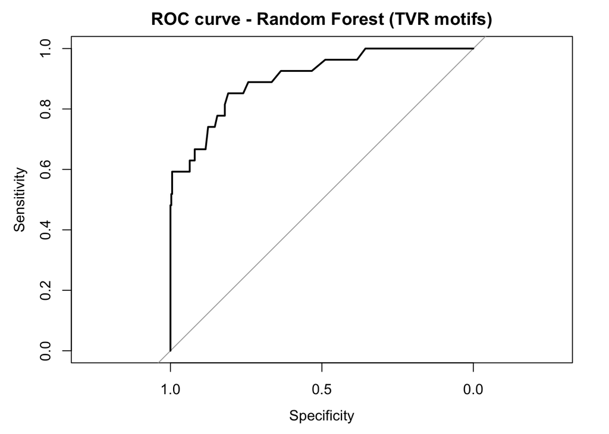

```r
plot(
  roc_rf,
  main = "ROC curve - Random Forest (TVR motifs)"
)
```

```r
auc(roc_rf)
```

```
## Area under the curve: 0.9026
```

The Random Forest classifier achieved an **AUC of 0.903**, indicating excellent discrimination between ALT-high and ALT-low tumors using only TVR motif features, and is slightly improved compared with the logistic regression model, suggesting that allowing **nonlinear relationships** between motifs provides **additional predictive power**.

### Other metrics

```r
rf_pred <- ifelse(rf_prob >= 0.5, "ALT-high", "ALT-low")
rf_pred <- factor(rf_pred, levels = c("ALT-low", "ALT-high"))

library(caret)

confusionMatrix(
  rf_pred,
  test$alt_status,
  positive = "ALT-high"
)
```

```
## Confusion Matrix and Statistics
##
##           Reference
## Prediction ALT-low ALT-high
##   ALT-low      360       11
##   ALT-high       2       16
##
##                Accuracy : 0.9666
##                  95% CI : (0.9435, 0.9821)
##     No Information Rate : 0.9306
##     P-Value [Acc > NIR] : 0.00169
##
##                   Kappa : 0.6941
##
##  Mcnemar's Test P-Value : 0.02650
##
##             Sensitivity : 0.59259
##             Specificity : 0.99448
##          Pos Pred Value : 0.88889
##          Neg Pred Value : 0.97035
##              Prevalence : 0.06941
##          Detection Rate : 0.04113
##    Detection Prevalence : 0.04627
##       Balanced Accuracy : 0.79353
##
##        'Positive' Class : ALT-high
##
```

### Feature importance

Random Forest’s big advantage is that we can perform **feature importance analysis**. With this, we can asses which motifs contribute the most to classification.

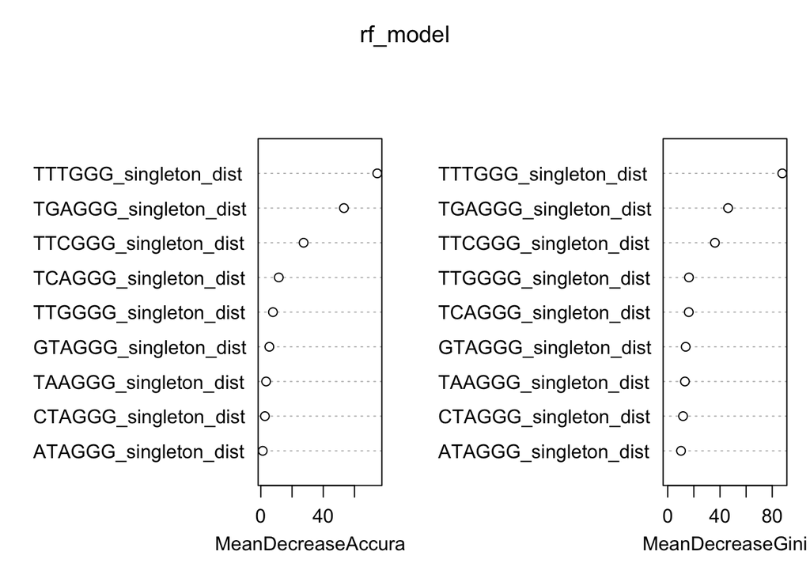

```r
varImpPlot(rf_model)
```

TTTGGG_singleton_dist emerges as the most influential predictor, followed by TGAGGG_singleton_dist and TTCGGG_singleton_dist. **This result is consistent with the earlier PCA analysis**, where these motifs also contributed substantially to the main axes of variation, reinforcing the conclusion that specific TVR patterns characterize ALT tumors.